# Технологический практикум (практикум на ЭВМ)

Рукавица Артём Кириллович, 316

2024-09-09

## 0. Описание датасета. Подготовка рабочего окружения

В качестве датасета для выполнения задания я выбрал данные о показателях сна и здоровья. Этот датасет состоит из нескольких столбцов:

1. Heart Rate Variability: Изменения интервалов между ударами сердца.
2. Body Temperature: Температура тела в градусах Цельсия.
3. Movement During Sleep: Количество движений во время сна.
4. Sleep Duration Hours: Длительность сна.
5. Sleep Quality Score: Качество сна.
6. Caffeine Intake (mg): Количество потребления кофеина в миллиграммах.
7. Stress Level: Уровень стресса.
8. Bedtime Consistency: Регулярность режима сна. Принимает значения из отрезка `[0; 1]`, где более низкие значения указывают на большую нерегулярность.
9. Light Exposure Hours: Часы воздействия света в течение дня. Отражает типичное дневное освещение.

Мы готовы начинать! Покдлючим библиотеки, а также датасет к рабочему окружению.

```r
library(xtable)
library(stargazer)
library(data.table)
library(dplyr)
library(ggplot2)
library(outliers)
library(forcats)
library(nortest)
library(goftest)
library(car)
library(Exact)
library(polycor)
library(reshape2)
library(RColorBrewer)
library(pwr)
```

```r
sleep <- read.csv("D:\\Artyom\\ВМК\\5 семестр\\Практикум\\SleepHealth.csv")
head(sleep)
```

```
##   HeartRateVariability BodyTemperature MovementDuringSleep SleepDurationHours
## 1             79.93428        37.19968           1.3248217           4.638289
## 2             67.23471        36.96232           1.8554813           6.209422
## 3             82.95377        36.52982           1.2075801           6.879592
## 4            100.46060        36.17653           1.6920385          10.331531
## 5             65.31693        36.84911           0.1063853           8.334830
## 6             65.31726        36.69674           2.2132937           5.496778
##   SleepQualityScore CaffeineIntakeMg StressLevel BedtimeConsistency
## 1          1.000000        107.62403    2.771837          0.6570370
## 2          1.000000        104.65859    3.738138          0.1444638
## 3         10.000000          0.00000    3.115880          0.6429491
## 4          1.000000        116.99098    3.904008          0.4532552
## 5          1.000000        223.28291    4.571699          0.6414915
## 6          7.122153         22.57679    6.674309          0.6553863
##   LightExposureHours
## 1           7.933949
## 2           6.992699
## 3           7.655250
## 4           9.429463
## 5          10.555713
## 6           9.140975
```

## 1. Описание, краткие характеристики (максимумы-минимумы, средние значения, пропуски и т.п.)

```r
table <- summary(sleep)
na <- data.frame(as.list(sapply(X = sleep, FUN = function(x) sum(is.na(x)))))
rownames(na) <- c("Count of NA")
table <- do.call(cbind, lapply(sleep, summary))
table <- rbind(table, na)
knitr::kable(table)
```

|  | HeartRateVariability | BodyTemperature | MovementDuringSleep | SleepDurationHours | SleepQualityScore | CaffeineIntakeMg | StressLevel | BedtimeConsistency | LightExposureHours |
| --- | --- | --- | --- | --- | --- | --- | --- | --- | --- |
| Min. | 5.174653 | 35.02981 | -1.019512 | 3.105827 | 1.000000 | 0.00000 | 0.000000 | 0.0000000 | 0.3266889 |
| 1st Qu. | 57.048194 | 36.19688 | 1.352000 | 6.393869 | 1.000000 | 80.63072 | 3.489725 | 0.3615688 | 6.7262910 |
| Median | 70.506012 | 36.53154 | 1.999749 | 7.500277 | 1.000000 | 145.71729 | 4.890507 | 0.5009960 | 8.0382479 |
| Mean | 70.386641 | 36.53542 | 2.005834 | 7.471921 | 2.592946 | 148.26015 | 4.940956 | 0.5042222 | 8.0366835 |
| 3rd Qu. | 82.958877 | 36.86444 | 2.660915 | 8.500418 | 2.537789 | 211.24468 | 6.399490 | 0.6446802 | 9.3544081 |
| Max. | 147.054630 | 38.09655 | 5.926238 | 12.364639 | 10.000000 | 400.00000 | 10.000000 | 1.0000000 | 14.7547658 |
| Count of NA | 0.000000 | 0.00000 | 0.000000 | 0.000000 | 0.000000 | 0.00000 | 0.000000 | 0.0000000 | 0.0000000 |

Обратим внимание на то, что пропусков в данных нет.

## 2. Реализовать аппроксимацию распределений данных с помощью ядерных оценок

Исследуем распределение столбца HeartRateVariability

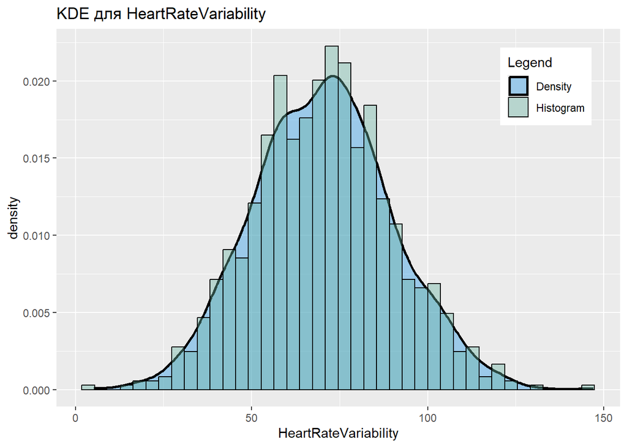

```r
ggplot(sleep, aes(x = HeartRateVariability)) +
  geom_density(aes(fill = "Density"), lwd = 1, alpha = 0.4) +
  geom_histogram(aes(y = ..density.., fill = "Histogram"),
                 colour = 1, alpha = 0.4, bins = 40) +
  scale_fill_manual(name = "Legend", values = c("Histogram" = "#69b3a2", "Density" = 4)) +
  ggtitle("KDE для HeartRateVariability") +
  theme(
    legend.position = c(.95, .95),
    legend.justification = c("right", "top"),
    legend.box.just = "right",
    legend.margin = margin(6, 6, 6, 6)
  )
```

1. Распределение для HeartRateVariability имеет симметричную колоколообразную фор му, схожую с нормальным распределением. Центр сосредоточен около среднего зна чения (порядка 70).
2. Выраженные выбросы отсутствуют.
3. Плотность, отображаемая KDE, согласуется с гистограммой, что подтверждает кор ректность метода сглаживания.

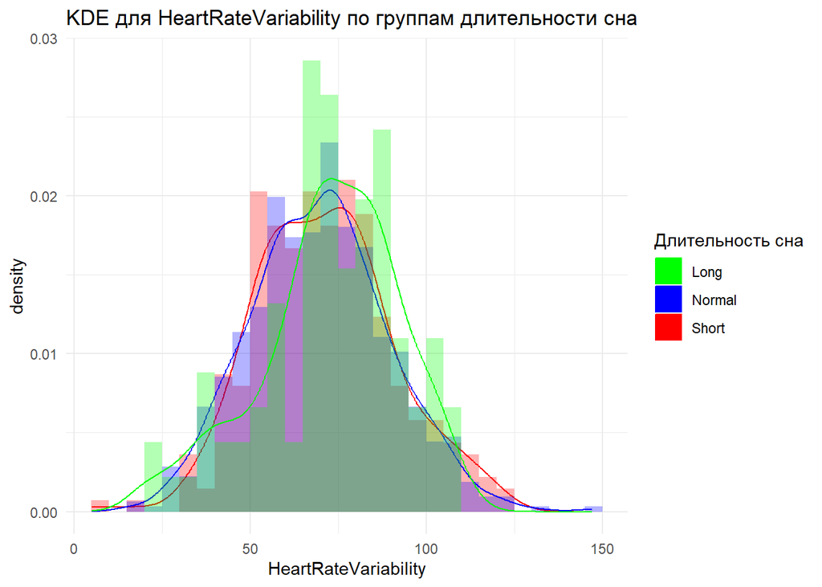

```r
sleep$SleepDurationHoursCorrected <- round(sleep$SleepDurationHours)
sleep$SleepDurationHoursGroups <- cut(sleep$SleepDurationHoursCorrected,
                                         breaks = c(2, 6, 9, 12),
                                         labels = c("Short", "Normal", "Long"),
                                         right=T)
edges <- hist(sleep$HeartRateVariability, breaks = "FD", plot = FALSE)$breaks

ggplot() +
  geom_histogram(data = filter(sleep, SleepDurationHoursGroups == 'Short'),
                 aes(x = HeartRateVariability, y = ..density.., fill = 'Short'),
                 breaks = edges, alpha = 0.3) +
  geom_density(data = filter(sleep, SleepDurationHoursGroups == 'Short'),
               aes(x = HeartRateVariability, color = 'Short')) +
  geom_histogram(data = filter(sleep, SleepDurationHoursGroups == 'Normal'),
                 aes(x = HeartRateVariability, y = ..density.., fill = 'Normal'),
                 breaks = edges, alpha = 0.3) +
  geom_density(data = filter(sleep, SleepDurationHoursGroups == 'Normal'),
               aes(x = HeartRateVariability, color = 'Normal')) +
  geom_histogram(data = filter(sleep, SleepDurationHoursGroups == 'Long'),
                 aes(x = HeartRateVariability, y = ..density.., fill = 'Long'),
                 breaks = edges, alpha = 0.3) +
  geom_density(data = filter(sleep, SleepDurationHoursGroups == 'Long'),
               aes(x = HeartRateVariability, color = 'Long')) +
  labs(x = 'HeartRateVariability',
       title = 'KDE для HeartRateVariability по группам длительности сна',
       fill = 'Длительность сна',
       color = 'Длительность сна') +
  theme_minimal() +
  scale_fill_manual(values = c('Short' = 'red', 'Normal' = 'blue', 'Long' = 'green')) +
  scale_color_manual(values = c('Short' = 'red', 'Normal' = 'blue', 'Long' = 'green'))
```

## 3. Реализовать анализ данных с помощью cdplot, dotchart, boxplot и stripchart

Для простоты анализа данных округлим значения длительности сна до целого числа.

```r
sleep$SleepDurationHoursCorrected <- round(sleep$SleepDurationHours)
unique(sleep$SleepDurationHoursCorrected)
```

```
##  [1]  5  6  7 10  8  9  3  4 11 12
```

Мы получили 10 натуральных значений от 3 до 12.

#### cdplot

Построим график зависимости сна от принятого кофеина.

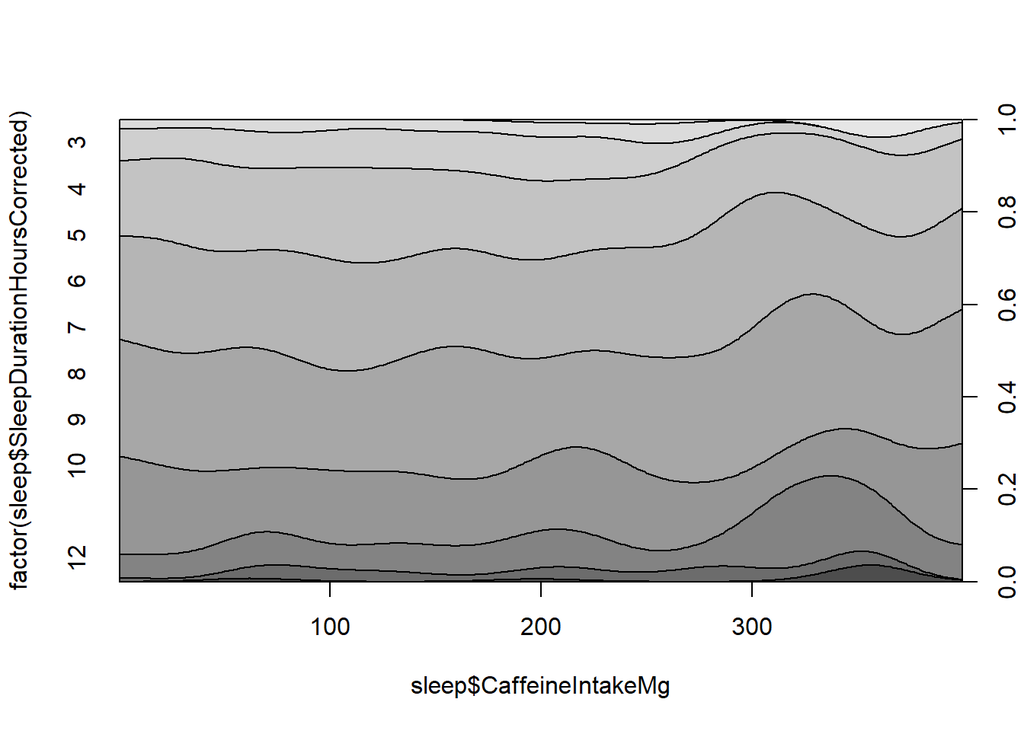

```r
cdplot(factor(sleep$SleepDurationHoursCorrected) ~ sleep$CaffeineIntakeMg)
```

На этом графике трудно разобраться, что к чему относится. Разделим для простоты длительность сна на три категории: короткий сон (3-6 часов), сон средней продолжительности (7-9 часов) и долгий сон (10-12 часов).

```r
sleep$SleepDurationHoursGroups <- cut(sleep$SleepDurationHoursCorrected,
                                         breaks = c(2, 6, 9, 12),
                                         labels = c("Short", "Normal", "Long"),
                                         right=T)
```

#### dotchart

Теперь построим dotplot зависимости среднего качества сна от его длительности.

[figure not shown]

```r
sleep$SleepQualityScore <- round(sleep$SleepQualityScore)
result <- aggregate(SleepQualityScore ~ SleepDurationHoursCorrected, data = sleep, FUN = mean)
dotchart(result$SleepQualityScore, labels = result$SleepDurationHoursCorrected,
         main = "Dotplot of Sleep Quality vs Mean of Sleep Duration",
         xlab = "Mean of Sleep Quality Scores",
         ylab = "Sleep Duration (Hours)")
```

#### boxplot

Для серии boxplot-ов для удобства разделим уровень стресса на четыре категории: низкий, средний, высокий, очень высокий.

```r
sleep$StressLevelGroup <- cut(sleep$StressLevel,
                              breaks = c(-1, 3, 6, 8, 10),
                              labels = c("Low", "Medium", "High", "Very High"),
                              right=T
                              )
```

Исследуем длительность сна от уровня стресса.

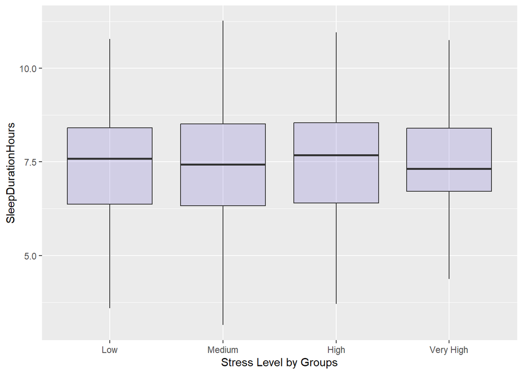

```r
ggplot(sleep, aes(x=as.factor(StressLevelGroup), y=SleepDurationHours)) +
  geom_boxplot(fill="slateblue", alpha=0.2, outliers = FALSE) +
  xlab("Stress Level by Groups")
```

Исследуем потребление кофеина от уровня стресса.

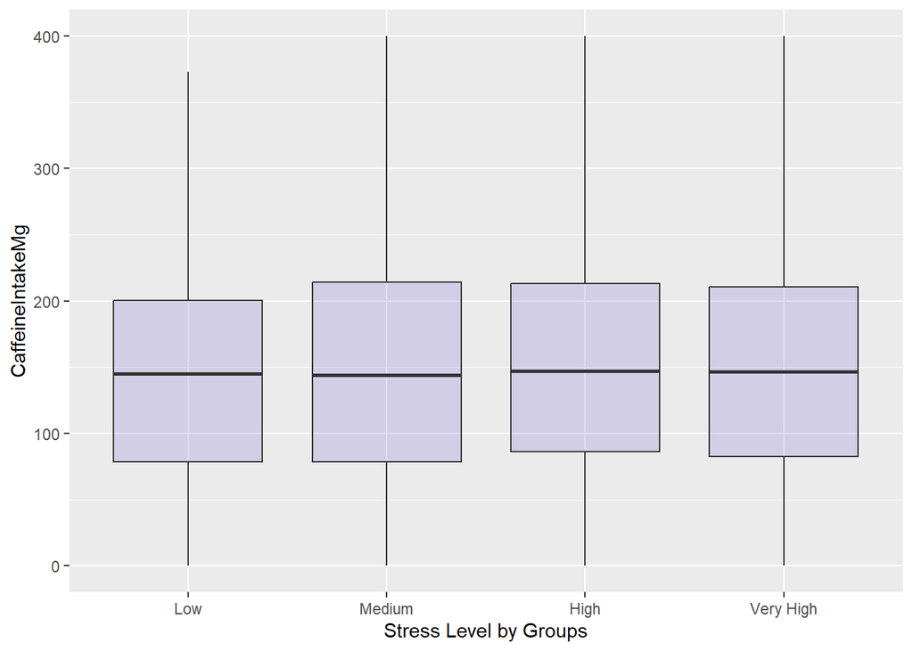

```r
ggplot(sleep, aes(x=as.factor(StressLevelGroup), y=CaffeineIntakeMg)) +
  geom_boxplot(fill="slateblue", alpha=0.2, outliers = FALSE) +
  xlab("Stress Level by Groups")
```

Исследуем количество движений во время сна от уровня стресса.

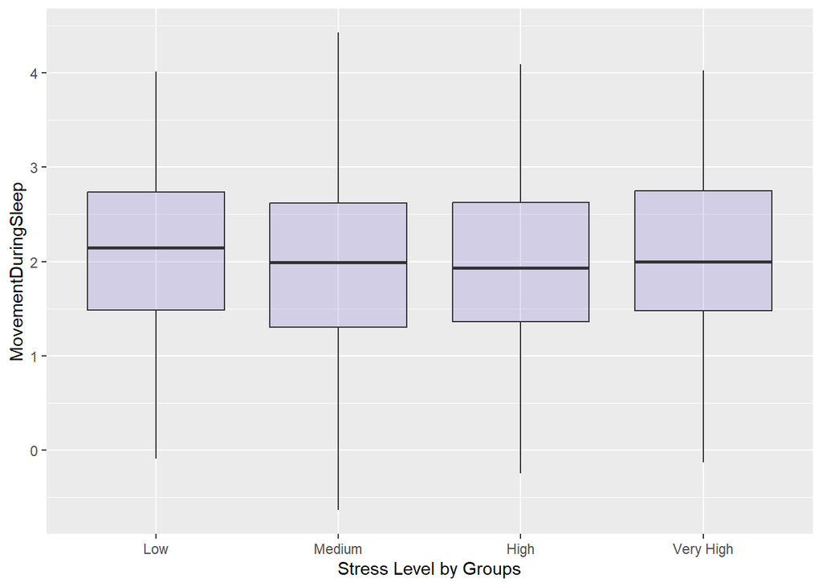

```r
ggplot(sleep, aes(x=as.factor(StressLevelGroup), y=MovementDuringSleep)) +
  geom_boxplot(fill="slateblue", alpha=0.2, outliers = FALSE) +
  xlab("Stress Level by Groups")
```

#### stripchart

[figure not shown]

```r
ggplot(sleep, aes(x = StressLevelGroup, y = CaffeineIntakeMg)) +
  geom_jitter(color = "blue", width = 0.1, height = 0) +
  labs(
    x = "Stress Level by Groups",
    y = "Caffeine Intake (mg)",
    title = "Stripchart of Sleep Duration by Stress Level Groups"
  ) +
  theme_minimal()
```

## 4. Проверить, являются ли наблюдения выбросами с точки зрения формальных статистических критериев Граббса и Q-теста Диксона.

Для этих критериев требуется нормальность выборки, проверим часть столбцов на нормальность при помощи критерия Шапиро — Уилка. Выведем p-значения этого критерия.

```r
paste("CaffeineIntakeMg: ", shapiro.test(sleep$CaffeineIntakeMg)$p.value)
```

```
## [1] "CaffeineIntakeMg:  4.48243641636406e-12"
```

```r
paste("StressLevel: ", shapiro.test(sleep$StressLevel)$p.value)
```

```
## [1] "StressLevel:  0.006355407774403"
```

```r
paste("LightExposureHours: ", shapiro.test(sleep$LightExposureHours)$p.value)
```

```
## [1] "LightExposureHours:  0.9574351010135"
```

```r
paste("MovementDuringSleep: ", shapiro.test(sleep$MovementDuringSleep)$p.value)
```

```
## [1] "MovementDuringSleep:  0.717817288266782"
```

Заметим, что p-значения первых двух тестов меньше порогового показателя 0.05, поэтому мы не можем сделать вывод о том, что выборки распределены нормально (критерии Граббса, Диксона неприменимы). Напротив, для последних двух выборок это возможно сделать. Убедимся на графике, что LightExposureHours и MovementDuringSleep действительно распределены нормально.

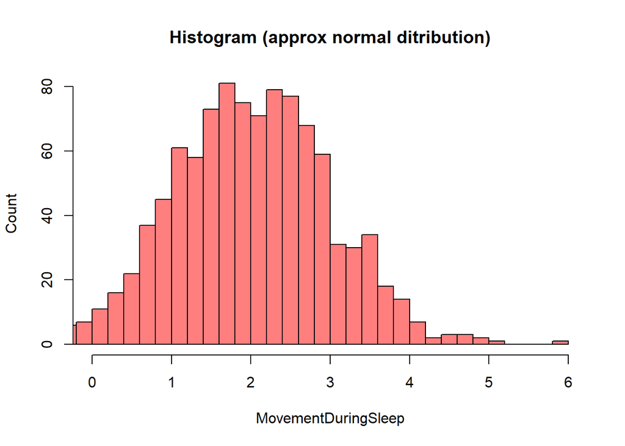

```r
hist(sleep$MovementDuringSleep, breaks=30 , xlim=c(0,6) ,
     col=rgb(1,0,0,0.5) ,
     xlab="MovementDuringSleep" ,
     ylab="Count" ,
     main="Histogram (approx normal ditribution)" )
```

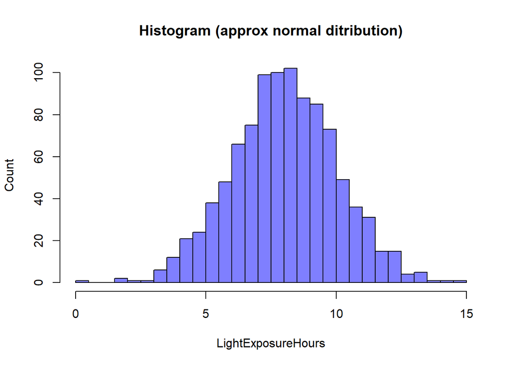

```r
hist(sleep$LightExposureHours, breaks=30 , xlim=c(0,15),
     col=rgb(0,0,1,0.5) ,
     xlab="LightExposureHours" ,
     ylab="Count" ,
     main="Histogram (approx normal ditribution)")
```

Исследуем показатель MovementDuringSleep на наличие выбросов.

Для простоты округлим этот показатель до двух знаков после запятой.

```r
sleep$MovementDuringSleep <- round(sleep$MovementDuringSleep, 2)
```

#### Тест Граббса

```r
test <- grubbs.test(sleep$MovementDuringSleep)
test
```

```
##
##  Grubbs test for one outlier
##
## data:  sleep$MovementDuringSleep
## G = 3.98980, U = 0.98405, p-value = 0.03103
## alternative hypothesis: highest value 5.93 is an outlier
```

Тест Граббса показывает, что значение 5.93 - это выброс. Убедимся в этом на классическом boxplot.

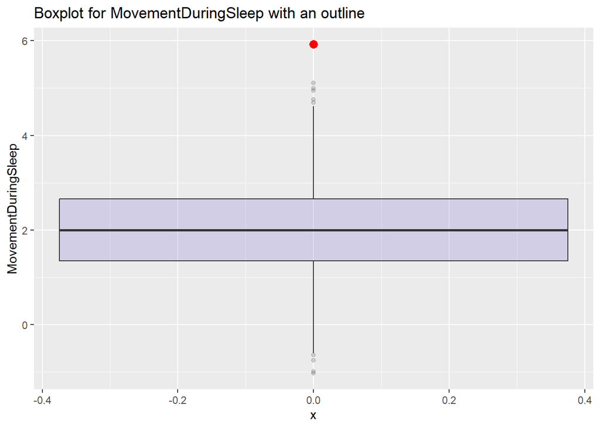

```r
ggplot(sleep, aes(y=MovementDuringSleep)) +
  geom_boxplot(fill="slateblue", alpha=0.2)+
  geom_point(aes(x=0, y=5.93), col="red", size=3)+
  ggtitle("Boxplot for MovementDuringSleep with an outline")
```

Действительно, 5.93 - выброс в наблюдении выборки MovementDuringSleep.

Посмотрим, какая строка набора данных соответствует этому значению…

```r
string <- filter(sleep, MovementDuringSleep == 5.93)
string
```

```
##   HeartRateVariability BodyTemperature MovementDuringSleep SleepDurationHours
## 1              82.9742        36.31499                5.93           9.002448
##   SleepQualityScore CaffeineIntakeMg StressLevel BedtimeConsistency
## 1                 1          250.673    3.922419          0.3901682
##   LightExposureHours SleepDurationHoursCorrected SleepDurationHoursGroups
## 1           12.09131                           9                   Normal
##   StressLevelGroup
## 1           Medium
```

… и какой индекс у этой строки в датасете.

```r
indices <- which(sleep$MovementDuringSleep == 5.93)
print(indices)
```

```
## [1] 896
```

#### Q-тест Диксона

```r
subdata <- sleep$MovementDuringSleep[890:910]
test <- dixon.test(subdata)
test
```

```
##
##  Dixon test for outliers
##
## data:  subdata
## Q = 0.48991, p-value = 0.04092
## alternative hypothesis: highest value 5.93 is an outlier
```

Результат такой же.

## 5. Воспользоваться инструментами для заполнения пропусков в данных. Пропуски внести вручную и сравнить результаты заполнения с истинными значениями.

Вспомним, что в данных нет пропусков.

```r
na <- data.frame(as.list(sapply(X = sleep, FUN = function(x) sum(is.na(x)))))
na
```

```
##   HeartRateVariability BodyTemperature MovementDuringSleep SleepDurationHours
## 1                    0               0                   0                  0
##   SleepQualityScore CaffeineIntakeMg StressLevel BedtimeConsistency
## 1                 0                0           0                  0
##   LightExposureHours SleepDurationHoursCorrected SleepDurationHoursGroups
## 1                  0                           0                        0
##   StressLevelGroup
## 1                0
```

Это не проблема: попробуем внести пропуски, например, в столбец BodyTemperature. Создаим массив из случайных 10 чисел. Значения, соответствующие данным индексам, обратим в NA.

```r
indices <- c(894, 2, 198, 753, 186, 78, 45, 187, 952, 886)
print(sleep$BodyTemperature[indices])
```

```
##  [1] 36.44520 36.96232 36.77624 36.17296 36.97039 36.28594 36.41369 36.00876
##  [9] 37.13096 36.64008
```

```r
print(median(sleep$BodyTemperature))
```

```
## [1] 36.53154
```

```r
print(mean(sleep$BodyTemperature))
```

```
## [1] 36.53542
```

```r
sleep$BodyTemperature[indices] <- NA
```

Проверим, удалились ли эти значения?

```r
sum(is.na(sleep$BodyTemperature))
```

```
## [1] 10
```

Все отлично! Теперь построим гистограмму для измененных данных.

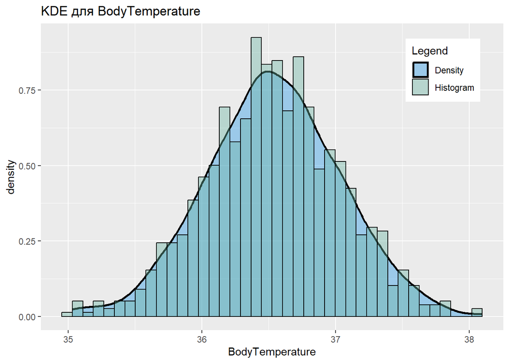

```r
ggplot(sleep, aes(x = BodyTemperature)) +
  geom_density(aes(fill = "Density"), lwd = 1, alpha = 0.4) +
  geom_histogram(aes(y = ..density.., fill = "Histogram"),
                 colour = 1, alpha = 0.4, bins = 40) +
  scale_fill_manual(name = "Legend", values = c("Histogram" = "#69b3a2", "Density" = 4)) +
  ggtitle("KDE для BodyTemperature") +
  theme(
    legend.position = c(.95, .95),
    legend.justification = c("right", "top"),
    legend.box.just = "right",
    legend.margin = margin(6, 6, 6, 6)
  )
```

Заполним пропущенные значения медианой.

```r
med <- median(sleep$BodyTemperature, na.rm = TRUE)
sleep$BodyTemperature[indices] <- median(sleep$BodyTemperature, na.rm = TRUE)
print(med)
```

```
## [1] 36.53154
```

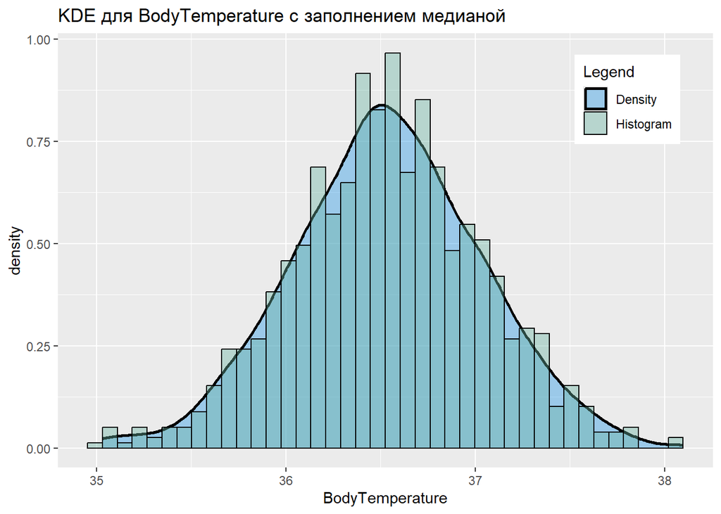

```r
ggplot(sleep, aes(x = BodyTemperature)) +
  geom_density(aes(fill = "Density"), lwd = 1, alpha = 0.4) +
  geom_histogram(aes(y = ..density.., fill = "Histogram"),
                 colour = 1, alpha = 0.4, bins = 40) +
  scale_fill_manual(name = "Legend", values = c("Histogram" = "#69b3a2", "Density" = 4)) +
  ggtitle("KDE для BodyTemperature с заполнением медианой") +
  theme(
    legend.position = c(.95, .95),
    legend.justification = c("right", "top"),
    legend.box.just = "right",
    legend.margin = margin(6, 6, 6, 6)
  )
```

Заполним пропущенные значения средним.

```r
me <- mean(sleep$BodyTemperature, na.rm = TRUE)
sleep$BodyTemperature[indices] <- mean(sleep$BodyTemperature, na.rm = TRUE)
print(me)
```

```
## [1] 36.53493
```

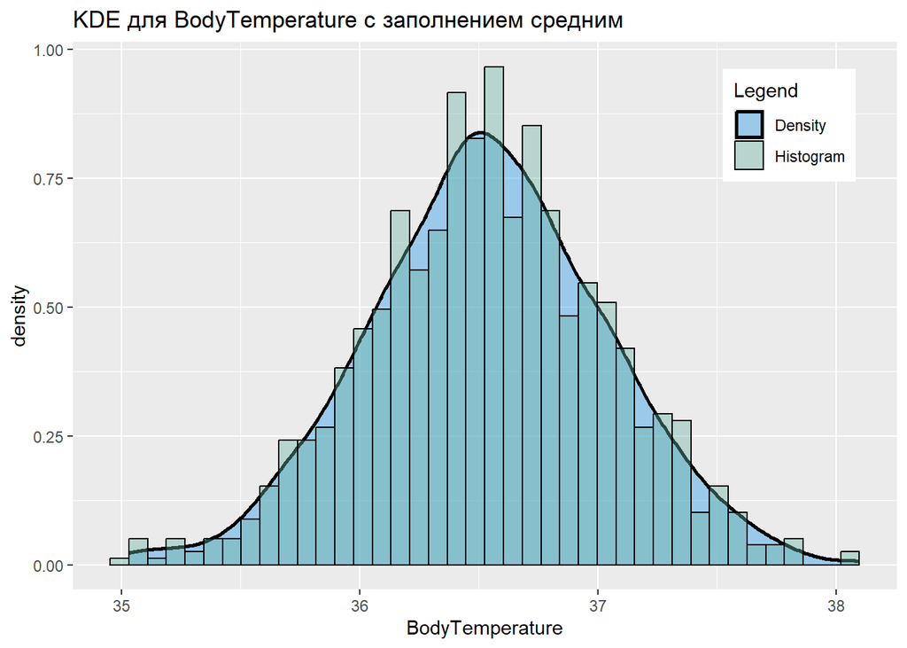

```r
ggplot(sleep, aes(x = BodyTemperature)) +
  geom_density(aes(fill = "Density"), lwd = 1, alpha = 0.4) +
  geom_histogram(aes(y = ..density.., fill = "Histogram"),
                 colour = 1, alpha = 0.4, bins = 40) +
  scale_fill_manual(name = "Legend", values = c("Histogram" = "#69b3a2", "Density" = 4)) +
  ggtitle("KDE для BodyTemperature с заполнением средним") +
  theme(
    legend.position = c(.95, .95),
    legend.justification = c("right", "top"),
    legend.box.just = "right",
    legend.margin = margin(6, 6, 6, 6)
  )
```

Можно сделать вывод о том, что методы заполнения пропусков медианными и средними значениями в целом дают довольно близкие результаты.

## 6. Анализ нормального распределения (на малых и больших выборках).

Сгенерируем выборки разных объемов с разными средними и дисперсиями.

```r
data1 <- rnorm(50, 0, 1)
data2 <- rnorm(100, 2, 2)
data3 <- rnorm(5000, 1, 4)
data4 <- rnorm(2000, 11, 3)
data5 <- rnorm(1000, 1, 1)
```

### Анализ с помощью графиков эмпирических функций распределений

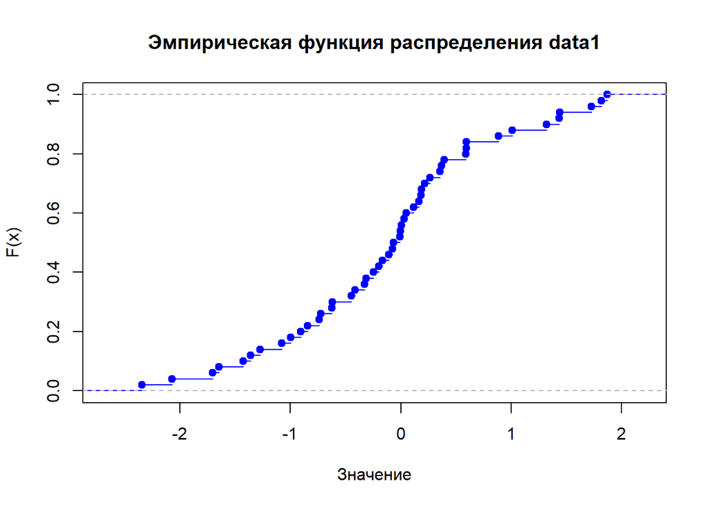

```r
plot(ecdf(data1), main = "Эмпирическая функция распределения data1",
     xlab = "Значение", ylab = "F(x)", col = "blue")
```

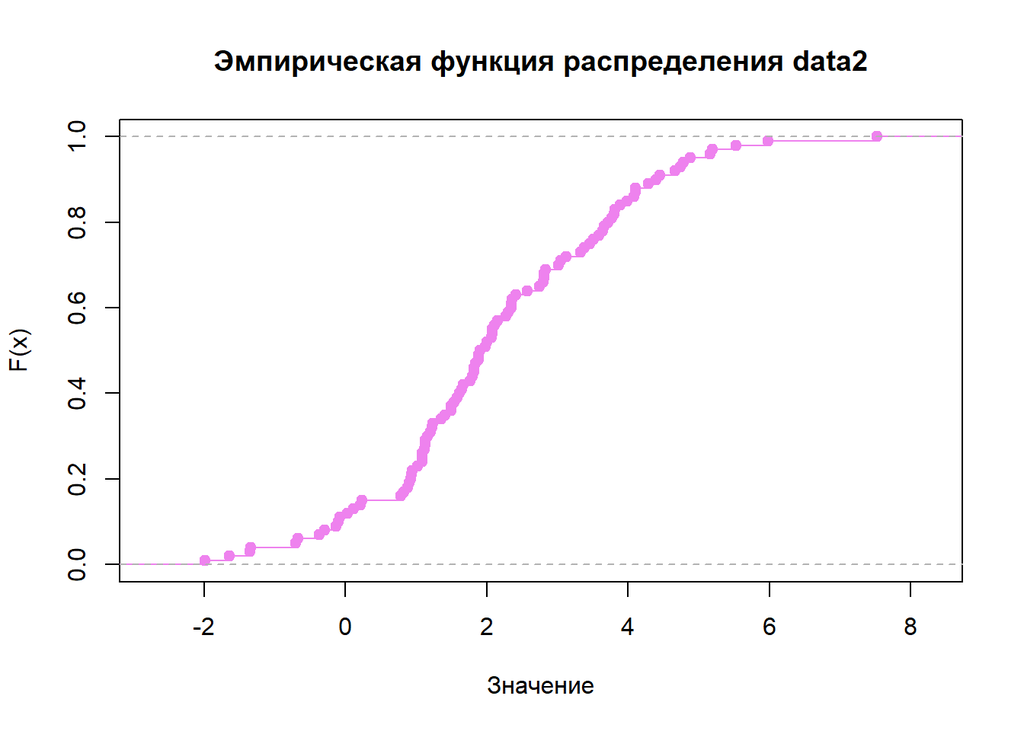

```r
plot(ecdf(data2), main = "Эмпирическая функция распределения data2",
     xlab = "Значение", ylab = "F(x)", col = "violet")
```

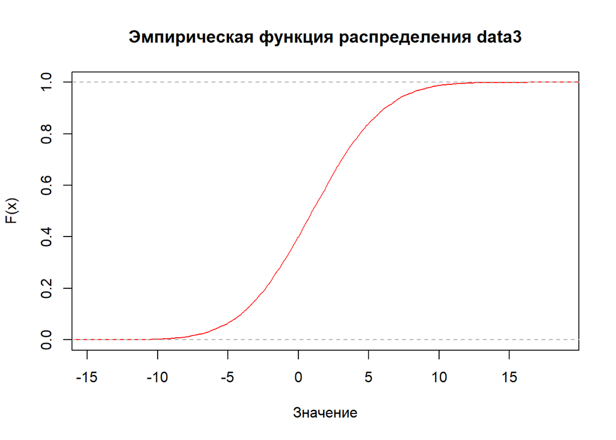

```r
plot(ecdf(data3), main = "Эмпирическая функция распределения data3",
     xlab = "Значение", ylab = "F(x)", col = "red")
```

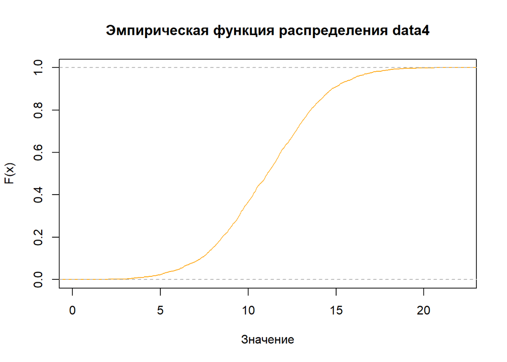

```r
plot(ecdf(data4), main = "Эмпирическая функция распределения data4",
     xlab = "Значение", ylab = "F(x)", col = "orange")
```

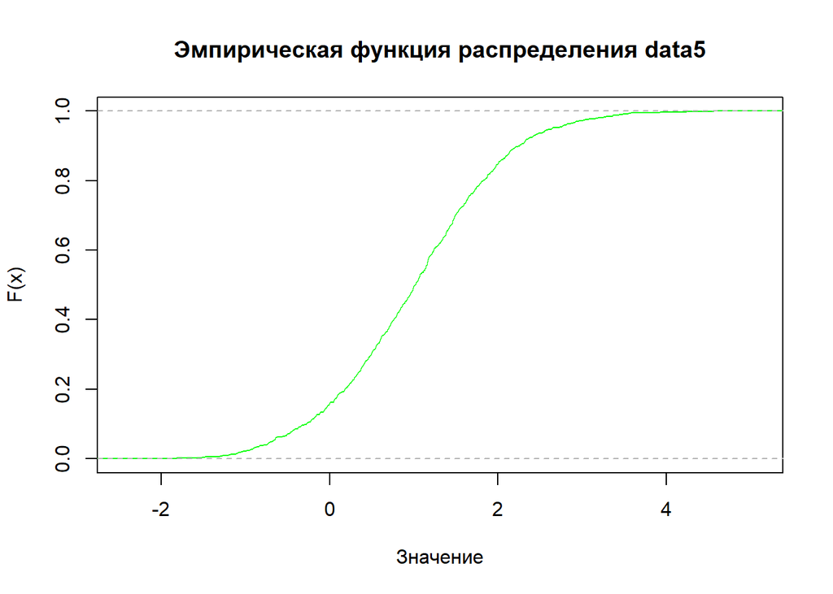

```r
plot(ecdf(data5), main = "Эмпирическая функция распределения data5",
     xlab = "Значение", ylab = "F(x)", col = "green")
```

Для интереса построим все эмпирические функции распределения на одном графике.

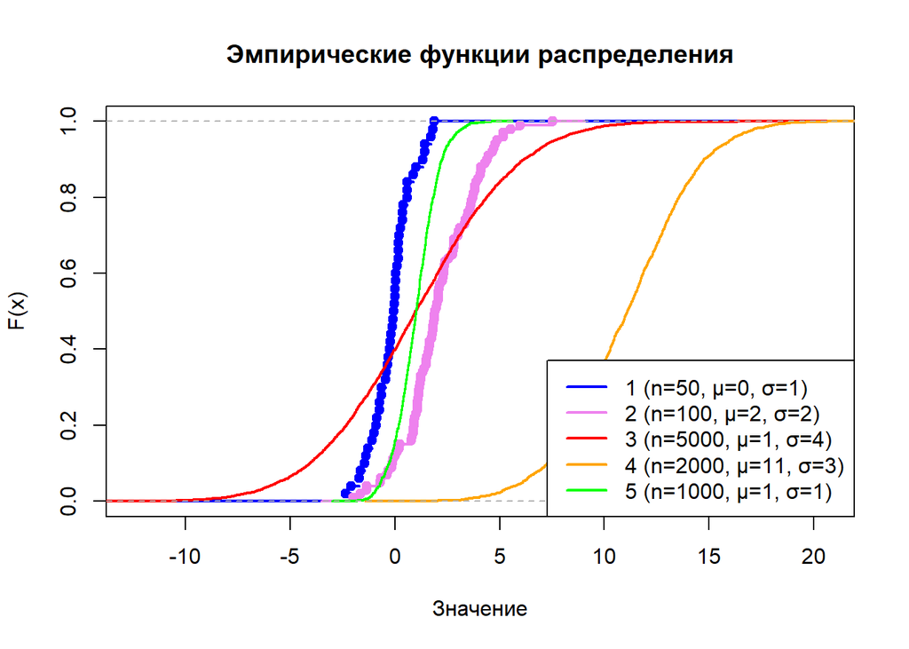

```r
x_range <- range(c(data1, data2, data3, data4, data5))
plot(ecdf(data1), main = "Эмпирические функции распределения",
     xlab = "Значение", ylab = "F(x)", col = "blue", lwd = 2, xlim=x_range)
lines(ecdf(data2), col = "violet", lwd = 2)
lines(ecdf(data3), col = "red", lwd = 2)
lines(ecdf(data4), col = "orange", lwd = 2)
lines(ecdf(data5), col = "green", lwd = 2)
legend("bottomright", legend = c("1 (n=50, μ=0, σ=1)",
                                 "2 (n=100, μ=2, σ=2)",
                                 "3 (n=5000, μ=1, σ=4)",
                                 "4 (n=2000, μ=11, σ=3)",
                                 "5 (n=1000, μ=1, σ=1)"
                                 ),
       col = c("blue", "violet", "red", "orange", "green"), lwd = 2)
```

### Анализ с помощью графиков квантилей

```r
qqgraph <- function(data, data_name="", color="") {
  qqnorm(data, pch = 1, main = paste("Q-Q график для нормальной выборки ", data_name),
       xlab = "Теоретические квантили", ylab = "Выборочные квантили")
  qqline(data, col = color, lwd = 2)
}
```

Теперь можно построить QQ-plot для наших нормальных выборок.

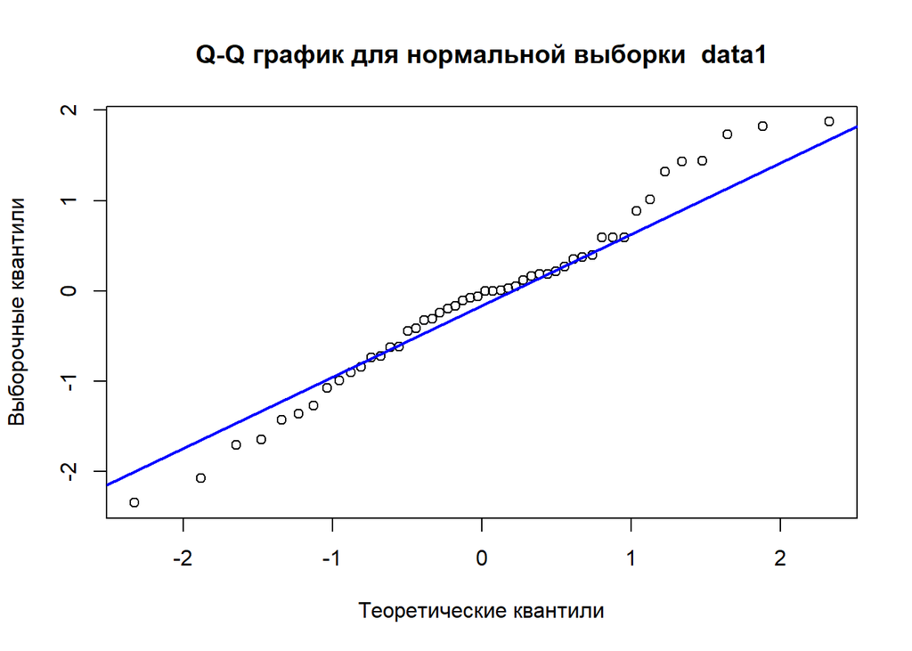

```r
qqgraph(data1, data_name="data1", color="blue")
```

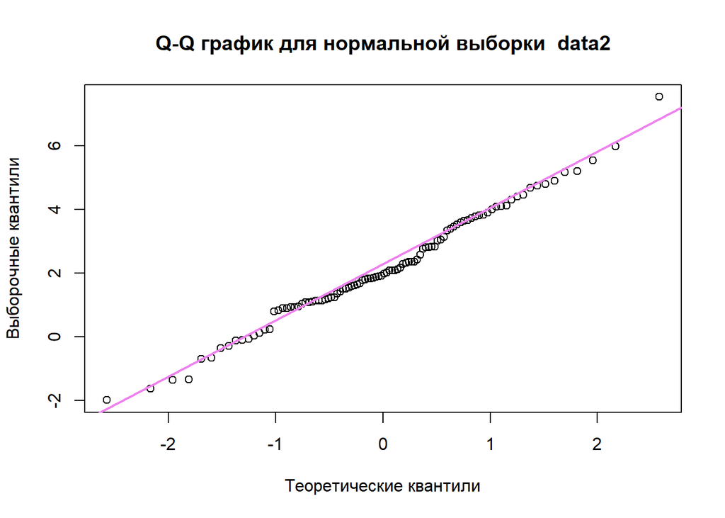

```r
qqgraph(data2, data_name="data2", color="violet")
```

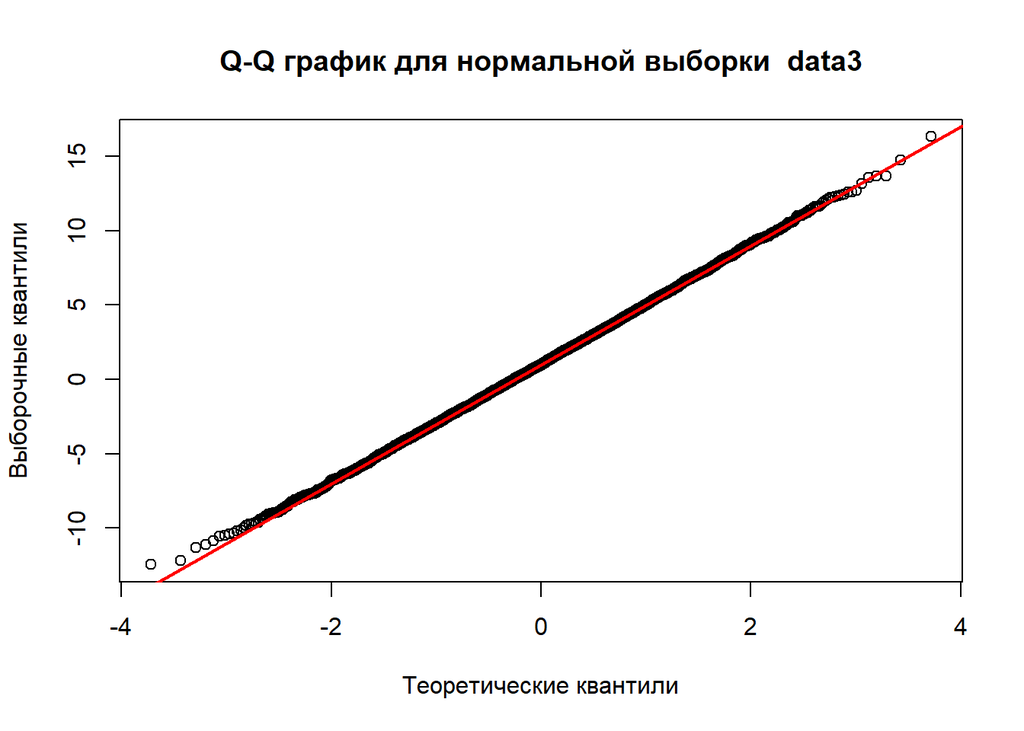

```r
qqgraph(data3, data_name="data3", color="red")
```

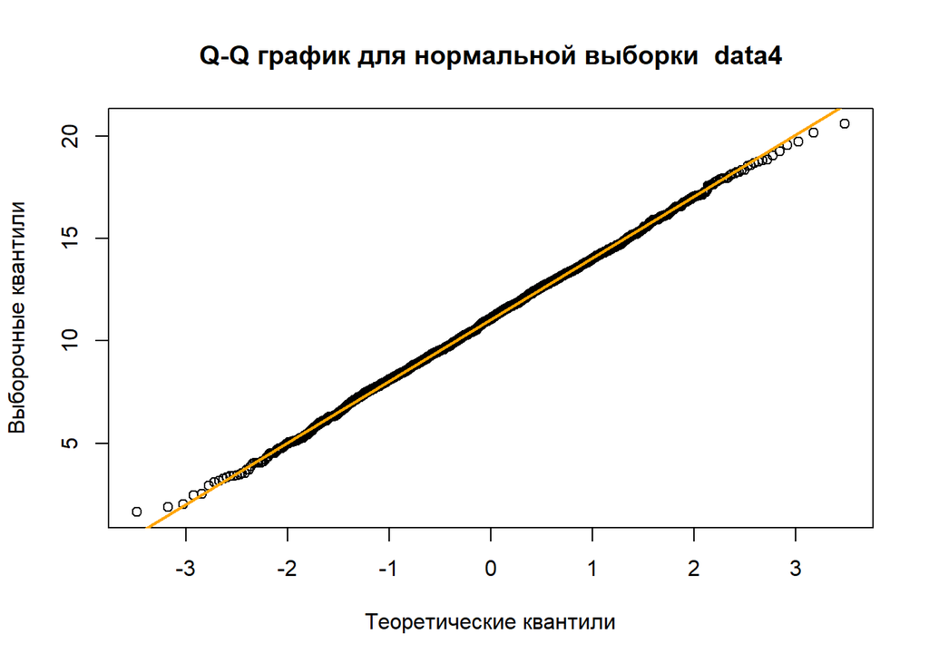

```r
qqgraph(data4, data_name="data4", color="orange")
```

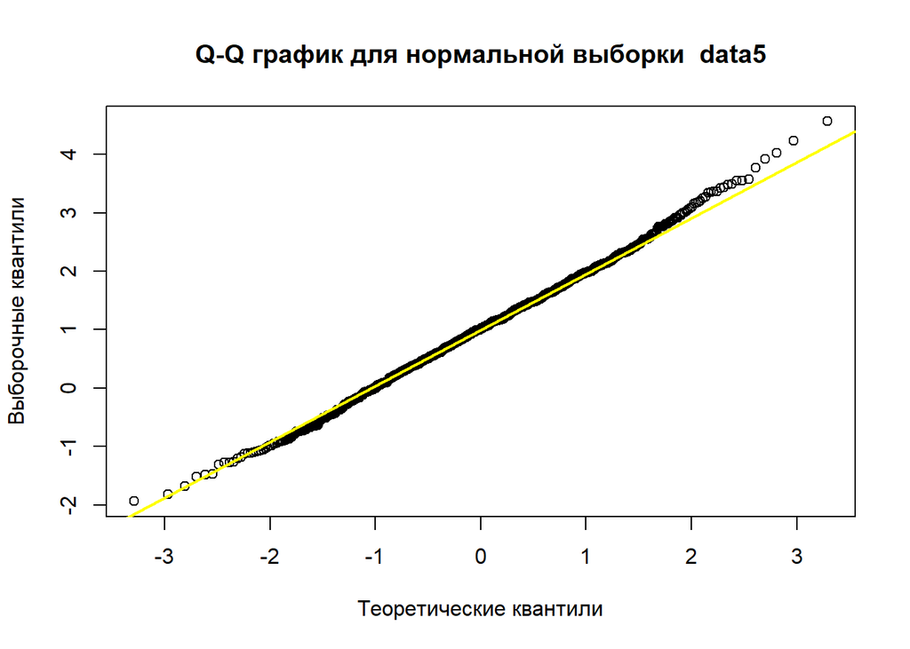

```r
qqgraph(data5, data_name="data5", color="yellow")
```

### Анализ с помощью метода огибающих

```r
my_envelope <- function(data, data_name="", color="") {
  qqPlot(data, dist = "norm", col = color, pch = 19,
       xlab = "Квантили нормального распределения",
       ylab = "Наблюдаемые квантили",
       main = paste("Метод огибающих для нормальной выборки ", data_name),
       envelope=list(level=0.99, col=color))
}
```

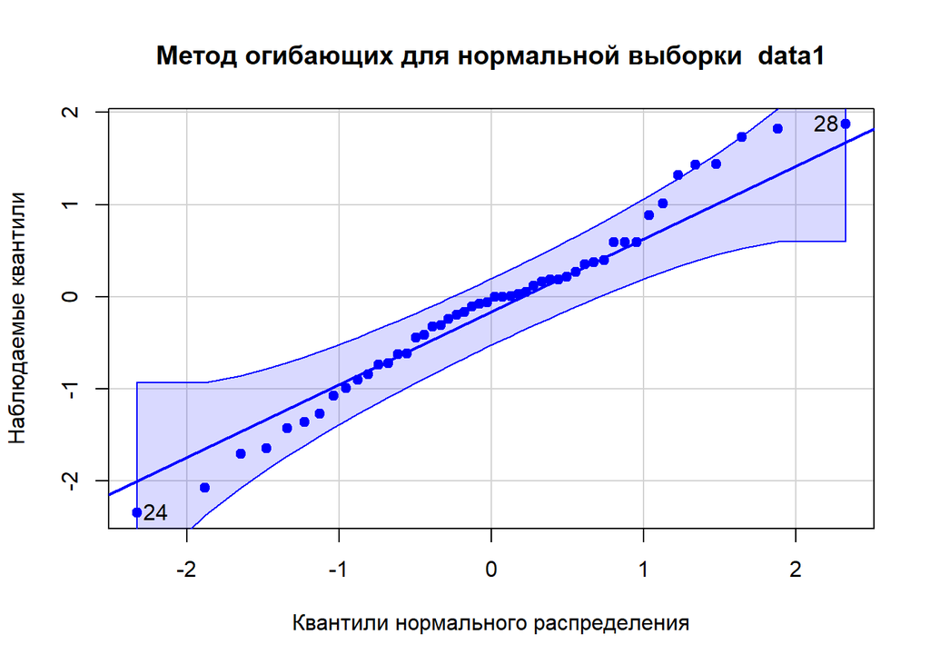

```
## [1] 24 28
```

```r
my_envelope(data1, data_name="data1", color="blue")
```

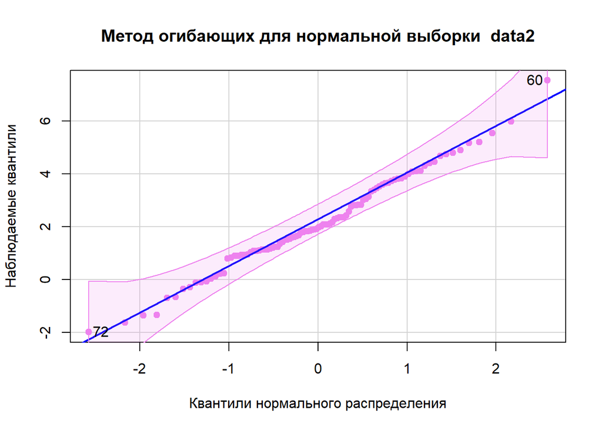

```
## [1] 60 72
```

```r
my_envelope(data2, data_name="data2", color="violet")
```

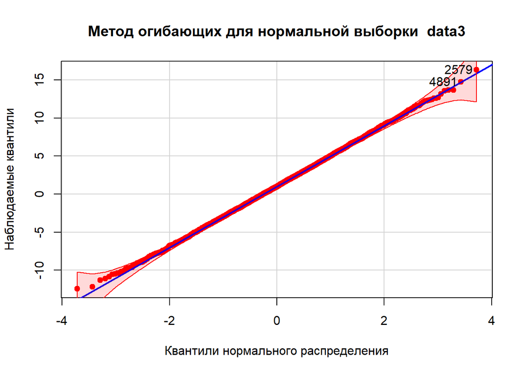

```
## [1] 2579 4891
```

```r
my_envelope(data3, data_name="data3", color="red")
```

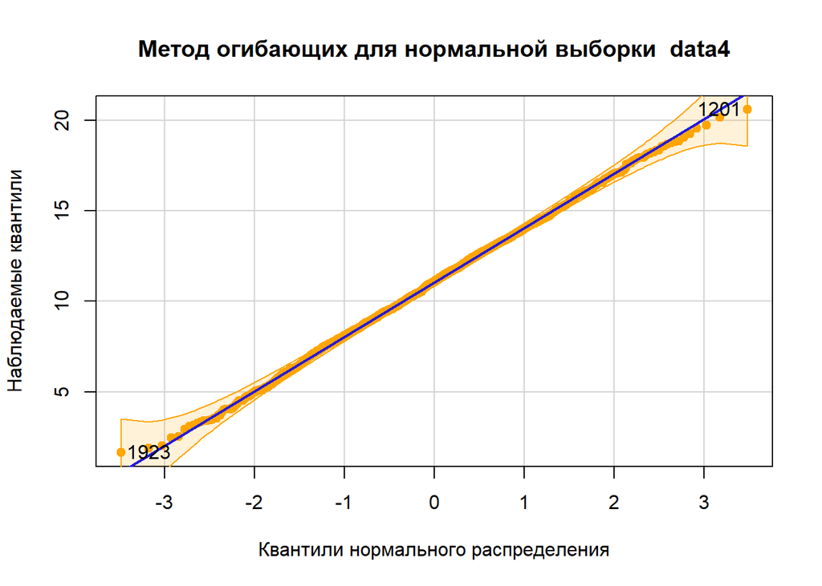

```
## [1] 1201 1923
```

```r
my_envelope(data4, data_name="data4", color="orange")
```

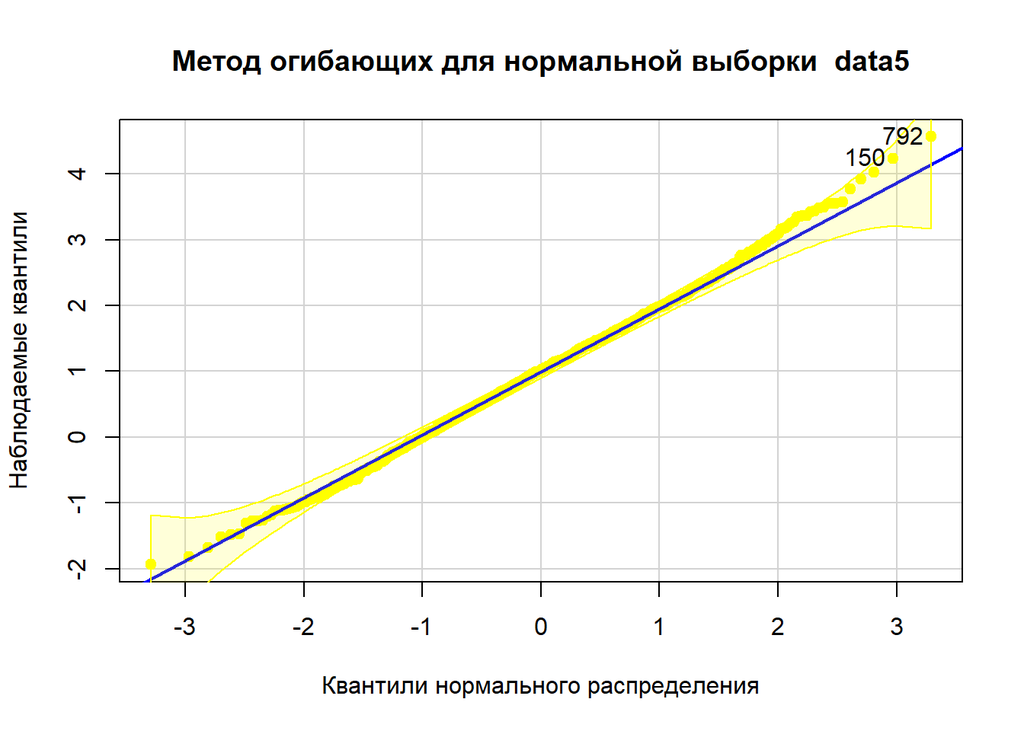

```
## [1] 792 150
```

```r
my_envelope(data5, data_name="data5", color="yellow")
```

### Стандартные процедуры проверки гипотез о нормальности.

#### 1. Критерий Колмогорова-Смирнова

Часто Критерий Колмогорова-Смирнова рассматривают как два отдельных критерия.

###### 1. Критерий согласия Колмогорова — служит для проверки гипотезы о принадлежности значений выборки к определенному теоретическому закону распределения.

```r
ks.test(data1, "pnorm", 0, 1)
```

```
##
##  Exact one-sample Kolmogorov-Smirnov test
##
## data:  data1
## D = 0.12738, p-value = 0.361
## alternative hypothesis: two-sided
```

```r
ks.test(data2, "pnorm", 2, 2)
```

```
##
##  Asymptotic one-sample Kolmogorov-Smirnov test
##
## data:  data2
## D = 0.12155, p-value = 0.1042
## alternative hypothesis: two-sided
```

```r
ks.test(data3, "pnorm", 1, 4)
```

```
##
##  Asymptotic one-sample Kolmogorov-Smirnov test
##
## data:  data3
## D = 0.0049159, p-value = 0.9997
## alternative hypothesis: two-sided
```

```r
ks.test(data4, "pnorm", 11, 3)
```

```
##
##  Asymptotic one-sample Kolmogorov-Smirnov test
##
## data:  data4
## D = 0.01768, p-value = 0.5594
## alternative hypothesis: two-sided
```

```r
ks.test(data5, "pnorm", 1, 1)
```

```
##
##  Asymptotic one-sample Kolmogorov-Smirnov test
##
## data:  data5
## D = 0.013443, p-value = 0.9936
## alternative hypothesis: two-sided
```

###### 2. Критерий однородности Смирнова — применяется для проверки гипотезы о принадлежности значений двух независимых выборок к одному и тому же закону распределения.

```r
ks.test(data1, data3)
```

```
##
##  Asymptotic two-sample Kolmogorov-Smirnov test
##
## data:  data1 and data3
## D = 0.4176, p-value = 6.344e-08
## alternative hypothesis: two-sided
```

```r
ks.test(data4, data5)
```

```
##
##  Asymptotic two-sample Kolmogorov-Smirnov test
##
## data:  data4 and data5
## D = 0.988, p-value < 2.2e-16
## alternative hypothesis: two-sided
```

В обоих случаях `p-value < 0.05`, поэтому выборки принадлежат разным распределениям.

#### 2. Критерий Шапиро-Уилка

```r
stats::shapiro.test(data1)
```

```
##
##  Shapiro-Wilk normality test
##
## data:  data1
## W = 0.98092, p-value = 0.5913
```

```r
stats::shapiro.test(data2)
```

```
##
##  Shapiro-Wilk normality test
##
## data:  data2
## W = 0.98982, p-value = 0.65
```

```r
stats::shapiro.test(data3)
```

```
##
##  Shapiro-Wilk normality test
##
## data:  data3
## W = 0.99981, p-value = 0.9619
```

```r
stats::shapiro.test(data4)
```

```
##
##  Shapiro-Wilk normality test
##
## data:  data4
## W = 0.99932, p-value = 0.7045
```

```r
stats::shapiro.test(data5)
```

```
##
##  Shapiro-Wilk normality test
##
## data:  data5
## W = 0.9984, p-value = 0.4893
```

Все данные распределены нормально, поскольку каждый тест выдал `p-value > 0.05`.

#### 3. Критерий Андерсона-Дарлинга

```r
nortest::ad.test(data1)
```

```
##
##  Anderson-Darling normality test
##
## data:  data1
## A = 0.35803, p-value = 0.4399
```

```r
nortest::ad.test(data2)
```

```
##
##  Anderson-Darling normality test
##
## data:  data2
## A = 0.42682, p-value = 0.3079
```

```r
nortest::ad.test(data3)
```

```
##
##  Anderson-Darling normality test
##
## data:  data3
## A = 0.12957, p-value = 0.9832
```

```r
nortest::ad.test(data4)
```

```
##
##  Anderson-Darling normality test
##
## data:  data4
## A = 0.31249, p-value = 0.5493
```

```r
nortest::ad.test(data5)
```

```
##
##  Anderson-Darling normality test
##
## data:  data5
## A = 0.27948, p-value = 0.6455
```

Все данные распределены нормально, поскольку каждый тест выдал `p-value > 0.05`.

#### 4. Критерий Крамера фон Мизеса

```r
cvm.test(data1, "pnorm", mean=0, sd=1)
```

```
##
##  Cramer-von Mises test of goodness-of-fit
##  Null hypothesis: Normal distribution
##  with parameters mean = 0, sd = 1
##  Parameters assumed to be fixed
##
## data:  data1
## omega2 = 0.12277, p-value = 0.4858
```

```r
cvm.test(data2, "pnorm", mean=2, sd=2)
```

```
##
##  Cramer-von Mises test of goodness-of-fit
##  Null hypothesis: Normal distribution
##  with parameters mean = 2, sd = 2
##  Parameters assumed to be fixed
##
## data:  data2
## omega2 = 0.17472, p-value = 0.3227
```

```r
cvm.test(data3, "pnorm", mean=1, sd=4)
```

```
##
##  Cramer-von Mises test of goodness-of-fit
##  Null hypothesis: Normal distribution
##  with parameters mean = 1, sd = 4
##  Parameters assumed to be fixed
##
## data:  data3
## omega2 = 0.013442, p-value = 0.9999
```

```r
cvm.test(data4, "pnorm", mean=11, sd=3)
```

```
##
##  Cramer-von Mises test of goodness-of-fit
##  Null hypothesis: Normal distribution
##  with parameters mean = 11, sd = 3
##  Parameters assumed to be fixed
##
## data:  data4
## omega2 = 0.11891, p-value = 0.4999
```

```r
cvm.test(data5, "pnorm", mean=1, sd=1)
```

```
##
##  Cramer-von Mises test of goodness-of-fit
##  Null hypothesis: Normal distribution
##  with parameters mean = 1, sd = 1
##  Parameters assumed to be fixed
##
## data:  data5
## omega2 = 0.035982, p-value = 0.9527
```

Все p-value больше 0.05, что указывает на то, что гипотеза о нормальности распределения данных не отклоняется для всех выборок.

#### 5. Критерий Колмогорова-Смирнова в модификации Лиллиефорса

```r
lillie.test(data1)
```

```
##
##  Lilliefors (Kolmogorov-Smirnov) normality test
##
## data:  data1
## D = 0.084637, p-value = 0.4959
```

```r
lillie.test(data2)
```

```
##
##  Lilliefors (Kolmogorov-Smirnov) normality test
##
## data:  data2
## D = 0.072729, p-value = 0.2162
```

```r
lillie.test(data3)
```

```
##
##  Lilliefors (Kolmogorov-Smirnov) normality test
##
## data:  data3
## D = 0.0051347, p-value = 0.988
```

```r
lillie.test(data4)
```

```
##
##  Lilliefors (Kolmogorov-Smirnov) normality test
##
## data:  data4
## D = 0.012864, p-value = 0.5851
```

```r
lillie.test(data5)
```

```
##
##  Lilliefors (Kolmogorov-Smirnov) normality test
##
## data:  data5
## D = 0.013797, p-value = 0.9159
```

Все данные распределены нормально, поскольку каждый тест выдал `p-value > 0.05`.

#### 6. Критерий Шапиро-Франсия

```r
sf.test(data1)
```

```
##
##  Shapiro-Francia normality test
##
## data:  data1
## W = 0.98369, p-value = 0.6206
```

```r
sf.test(data2)
```

```
##
##  Shapiro-Francia normality test
##
## data:  data2
## W = 0.98885, p-value = 0.4886
```

```r
sf.test(data3)
```

```
##
##  Shapiro-Francia normality test
##
## data:  data3
## W = 0.99984, p-value = 0.9766
```

```r
sf.test(data4)
```

```
##
##  Shapiro-Francia normality test
##
## data:  data4
## W = 0.99948, p-value = 0.8514
```

```r
sf.test(data5)
```

```
##
##  Shapiro-Francia normality test
##
## data:  data5
## W = 0.99846, p-value = 0.4712
```

Все данные распределены нормально, поскольку каждый тест выдал `p-value > 0.05`.

## 7. Продемонстрировать пример анализа данных с помощью графиков квантилей, метода огибающих, а также стандартных процедур проверки гипотез о нормальности. Рассмотреть выборки малого и умеренного объемов.

Начнем с выборки малого объема. Для этого я воспользуюсь новым датасетом, содержащем информацию о 77 видах хлопьев (https://www.kaggle.com/datasets/crawford/80-cereals).

Поля в наборе данных:

1. Name: Название хлопьев
2. mfr: Производитель хлопьев

2.1. A = American Home Food Products;

2.2. G = General Mills;

2.3. K = Kelloggs;

2.4. N = Nabisco;

2.5. P = Post;

2.6. Q = Quaker Oats;

2.7. R = Ralston Purina

3. type:

3.1. cold = холодные хлопья

3.2. hot = горячие хлопья

4. calories: калорийность на порцию
5. protein: граммы белка
6. fat: граммы жира
7. sodium: миллиграммы натрия
8. fiber: граммы пищевых волокон
9. carbo: граммы сложных углеводов
10. sugars: граммы сахара
11. potass: миллиграммы калия
12. vitamins: витамины и минералы — 0, 25 или 100, указывающие типичный процент от рекомендуемой нормы FDA
13. shelf: номер полки для демонстрации (1, 2 или 3, считая от пола)
14. weight: вес одной порции в унциях
15. cups: количество чашек в одной порции
16. rating: рейтинг хлопьев (Возможно, из Consumer Reports?)

Изучим, как распределены различные характеристики хлопьев в этом датасете.

Для начала загрузим датасет в окружение.

```r
cereal <- read.csv("D:\\Artyom\\ВМК\\5 семестр\\Практикум\\Cereal.csv")
head(cereal)
```

```
##                        name mfr type calories protein fat sodium fiber carbo
## 1                 100% Bran   N    C       70       4   1    130  10.0   5.0
## 2         100% Natural Bran   Q    C      120       3   5     15   2.0   8.0
## 3                  All-Bran   K    C       70       4   1    260   9.0   7.0
## 4 All-Bran with Extra Fiber   K    C       50       4   0    140  14.0   8.0
## 5            Almond Delight   R    C      110       2   2    200   1.0  14.0
## 6   Apple Cinnamon Cheerios   G    C      110       2   2    180   1.5  10.5
##   sugars potass vitamins shelf weight cups   rating
## 1      6    280       25     3      1 0.33 68.40297
## 2      8    135        0     3      1 1.00 33.98368
## 3      5    320       25     3      1 0.33 59.42551
## 4      0    330       25     3      1 0.50 93.70491
## 5      8     -1       25     3      1 0.75 34.38484
## 6     10     70       25     1      1 0.75 29.50954
```

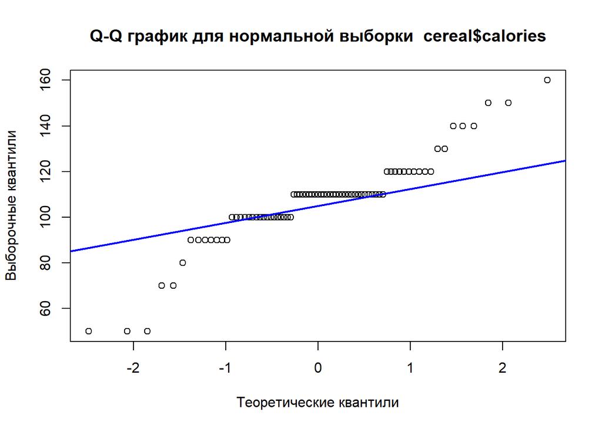

```r
qqgraph(cereal$calories, data_name="cereal$calories", color="blue")
```

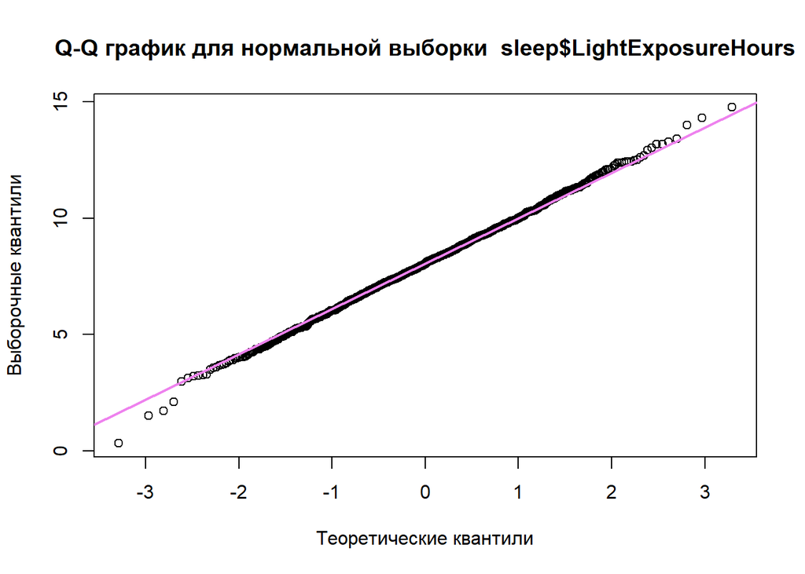

```r
qqgraph(sleep$LightExposureHours, data_name="sleep$LightExposureHours", color="violet")
```